# Risk Factor Analysis

## Outcome Variable

**Outcome Variable:** ever_stunted

## Predictor Variables

**Intervention Variable:** nchldlt5

**Adjustment Set:**

- arm
- W_mage
- meducyrs
- feducyrs
- hhwealth_quart
- hfoodsec
- W_mhtcm
- W_mwtkg
- W_mbmi
- W_nrooms
- W_parity
- impfloor
- impsan
- safeh20
- delta_W_mage
- delta_meducyrs
- delta_feducyrs
- delta_hhwealth_quart
- delta_hfoodsec
- delta_W_mhtcm
- delta_W_mwtkg
- delta_W_mbmi
- delta_W_nrooms
- delta_W_parity
- delta_impfloor
- delta_impsan
- delta_safeh20

## Stratifying Variables

The analysis was stratified on these variable(s):

- agecat
- studyid
- country

## Data Summary

| agecat | studyid | country | nchldlt5 | ever_stunted | n_cell | n |
| --- | --- | --- | --- | --- | --- | --- |
| 0-24 months | iLiNS-Zinc | BURKINA FASO | 1 | 0 | 711 | 3188 |
| 0-24 months | iLiNS-Zinc | BURKINA FASO | 1 | 1 | 362 | 3188 |
| 0-24 months | iLiNS-Zinc | BURKINA FASO | 2+ | 0 | 1339 | 3188 |
| 0-24 months | iLiNS-Zinc | BURKINA FASO | 2+ | 1 | 776 | 3188 |
| 0-24 months | IRC | INDIA | 1 | 0 | 35 | 410 |
| 0-24 months | IRC | INDIA | 1 | 1 | 54 | 410 |
| 0-24 months | IRC | INDIA | 2+ | 0 | 112 | 410 |
| 0-24 months | IRC | INDIA | 2+ | 1 | 209 | 410 |
| 0-24 months | JiVitA-3 | BANGLADESH | 1 | 0 | 8536 | 27200 |
| 0-24 months | JiVitA-3 | BANGLADESH | 1 | 1 | 8874 | 27200 |
| 0-24 months | JiVitA-3 | BANGLADESH | 2+ | 0 | 5189 | 27200 |
| 0-24 months | JiVitA-3 | BANGLADESH | 2+ | 1 | 4601 | 27200 |
| 0-24 months | LCNI-5 | MALAWI | 1 | 0 | 145 | 812 |
| 0-24 months | LCNI-5 | MALAWI | 1 | 1 | 246 | 812 |
| 0-24 months | LCNI-5 | MALAWI | 2+ | 0 | 150 | 812 |
| 0-24 months | LCNI-5 | MALAWI | 2+ | 1 | 271 | 812 |
| 0-24 months | NIH-Crypto | BANGLADESH | 1 | 0 | 298 | 758 |
| 0-24 months | NIH-Crypto | BANGLADESH | 1 | 1 | 243 | 758 |
| 0-24 months | NIH-Crypto | BANGLADESH | 2+ | 0 | 98 | 758 |
| 0-24 months | NIH-Crypto | BANGLADESH | 2+ | 1 | 119 | 758 |
| 0-24 months | PROVIDE | BANGLADESH | 1 | 0 | 295 | 700 |
| 0-24 months | PROVIDE | BANGLADESH | 1 | 1 | 217 | 700 |
| 0-24 months | PROVIDE | BANGLADESH | 2+ | 0 | 100 | 700 |
| 0-24 months | PROVIDE | BANGLADESH | 2+ | 1 | 88 | 700 |
| 0-24 months | TanzaniaChild2 | TANZANIA, UNITED REPUBLIC OF | 1 | 0 | 1077 | 2385 |
| 0-24 months | TanzaniaChild2 | TANZANIA, UNITED REPUBLIC OF | 1 | 1 | 560 | 2385 |
| 0-24 months | TanzaniaChild2 | TANZANIA, UNITED REPUBLIC OF | 2+ | 0 | 481 | 2385 |
| 0-24 months | TanzaniaChild2 | TANZANIA, UNITED REPUBLIC OF | 2+ | 1 | 267 | 2385 |
| 0-6 months | IRC | INDIA | 1 | 0 | 49 | 410 |
| 0-6 months | IRC | INDIA | 1 | 1 | 40 | 410 |
| 0-6 months | IRC | INDIA | 2+ | 0 | 187 | 410 |
| 0-6 months | IRC | INDIA | 2+ | 1 | 134 | 410 |
| 0-6 months | JiVitA-3 | BANGLADESH | 1 | 0 | 9780 | 27134 |
| 0-6 months | JiVitA-3 | BANGLADESH | 1 | 1 | 7579 | 27134 |
| 0-6 months | JiVitA-3 | BANGLADESH | 2+ | 0 | 6146 | 27134 |
| 0-6 months | JiVitA-3 | BANGLADESH | 2+ | 1 | 3629 | 27134 |
| 0-6 months | LCNI-5 | MALAWI | 1 | 0 | 81 | 267 |
| 0-6 months | LCNI-5 | MALAWI | 1 | 1 | 41 | 267 |
| 0-6 months | LCNI-5 | MALAWI | 2+ | 0 | 91 | 267 |
| 0-6 months | LCNI-5 | MALAWI | 2+ | 1 | 54 | 267 |
| 0-6 months | NIH-Crypto | BANGLADESH | 1 | 0 | 386 | 758 |
| 0-6 months | NIH-Crypto | BANGLADESH | 1 | 1 | 155 | 758 |
| 0-6 months | NIH-Crypto | BANGLADESH | 2+ | 0 | 143 | 758 |
| 0-6 months | NIH-Crypto | BANGLADESH | 2+ | 1 | 74 | 758 |
| 0-6 months | PROVIDE | BANGLADESH | 1 | 0 | 383 | 700 |
| 0-6 months | PROVIDE | BANGLADESH | 1 | 1 | 129 | 700 |
| 0-6 months | PROVIDE | BANGLADESH | 2+ | 0 | 149 | 700 |
| 0-6 months | PROVIDE | BANGLADESH | 2+ | 1 | 39 | 700 |
| 0-6 months | TanzaniaChild2 | TANZANIA, UNITED REPUBLIC OF | 1 | 0 | 1311 | 2385 |
| 0-6 months | TanzaniaChild2 | TANZANIA, UNITED REPUBLIC OF | 1 | 1 | 326 | 2385 |
| 0-6 months | TanzaniaChild2 | TANZANIA, UNITED REPUBLIC OF | 2+ | 0 | 609 | 2385 |
| 0-6 months | TanzaniaChild2 | TANZANIA, UNITED REPUBLIC OF | 2+ | 1 | 139 | 2385 |
| 6-24 months | iLiNS-Zinc | BURKINA FASO | 1 | 0 | 711 | 3188 |
| 6-24 months | iLiNS-Zinc | BURKINA FASO | 1 | 1 | 362 | 3188 |
| 6-24 months | iLiNS-Zinc | BURKINA FASO | 2+ | 0 | 1339 | 3188 |
| 6-24 months | iLiNS-Zinc | BURKINA FASO | 2+ | 1 | 776 | 3188 |
| 6-24 months | IRC | INDIA | 1 | 0 | 35 | 236 |
| 6-24 months | IRC | INDIA | 1 | 1 | 14 | 236 |
| 6-24 months | IRC | INDIA | 2+ | 0 | 112 | 236 |
| 6-24 months | IRC | INDIA | 2+ | 1 | 75 | 236 |
| 6-24 months | JiVitA-3 | BANGLADESH | 1 | 0 | 5238 | 10487 |
| 6-24 months | JiVitA-3 | BANGLADESH | 1 | 1 | 1295 | 10487 |
| 6-24 months | JiVitA-3 | BANGLADESH | 2+ | 0 | 2982 | 10487 |
| 6-24 months | JiVitA-3 | BANGLADESH | 2+ | 1 | 972 | 10487 |
| 6-24 months | LCNI-5 | MALAWI | 1 | 0 | 138 | 705 |
| 6-24 months | LCNI-5 | MALAWI | 1 | 1 | 205 | 705 |
| 6-24 months | LCNI-5 | MALAWI | 2+ | 0 | 145 | 705 |
| 6-24 months | LCNI-5 | MALAWI | 2+ | 1 | 217 | 705 |
| 6-24 months | NIH-Crypto | BANGLADESH | 1 | 0 | 280 | 506 |
| 6-24 months | NIH-Crypto | BANGLADESH | 1 | 1 | 88 | 506 |
| 6-24 months | NIH-Crypto | BANGLADESH | 2+ | 0 | 93 | 506 |
| 6-24 months | NIH-Crypto | BANGLADESH | 2+ | 1 | 45 | 506 |
| 6-24 months | PROVIDE | BANGLADESH | 1 | 0 | 238 | 456 |
| 6-24 months | PROVIDE | BANGLADESH | 1 | 1 | 88 | 456 |
| 6-24 months | PROVIDE | BANGLADESH | 2+ | 0 | 81 | 456 |
| 6-24 months | PROVIDE | BANGLADESH | 2+ | 1 | 49 | 456 |
| 6-24 months | TanzaniaChild2 | TANZANIA, UNITED REPUBLIC OF | 1 | 0 | 858 | 1596 |
| 6-24 months | TanzaniaChild2 | TANZANIA, UNITED REPUBLIC OF | 1 | 1 | 234 | 1596 |
| 6-24 months | TanzaniaChild2 | TANZANIA, UNITED REPUBLIC OF | 2+ | 0 | 376 | 1596 |
| 6-24 months | TanzaniaChild2 | TANZANIA, UNITED REPUBLIC OF | 2+ | 1 | 128 | 1596 |

The following strata were considered:

- agecat: 0-24 months, studyid: iLiNS-Zinc, country: BURKINA FASO
- agecat: 0-24 months, studyid: IRC, country: INDIA
- agecat: 0-24 months, studyid: JiVitA-3, country: BANGLADESH
- agecat: 0-24 months, studyid: LCNI-5, country: MALAWI
- agecat: 0-24 months, studyid: NIH-Crypto, country: BANGLADESH
- agecat: 0-24 months, studyid: PROVIDE, country: BANGLADESH
- agecat: 0-24 months, studyid: TanzaniaChild2, country: TANZANIA, UNITED REPUBLIC OF
- agecat: 0-6 months, studyid: IRC, country: INDIA
- agecat: 0-6 months, studyid: JiVitA-3, country: BANGLADESH
- agecat: 0-6 months, studyid: LCNI-5, country: MALAWI
- agecat: 0-6 months, studyid: NIH-Crypto, country: BANGLADESH
- agecat: 0-6 months, studyid: PROVIDE, country: BANGLADESH
- agecat: 0-6 months, studyid: TanzaniaChild2, country: TANZANIA, UNITED REPUBLIC OF
- agecat: 6-24 months, studyid: iLiNS-Zinc, country: BURKINA FASO
- agecat: 6-24 months, studyid: IRC, country: INDIA
- agecat: 6-24 months, studyid: JiVitA-3, country: BANGLADESH
- agecat: 6-24 months, studyid: LCNI-5, country: MALAWI
- agecat: 6-24 months, studyid: NIH-Crypto, country: BANGLADESH
- agecat: 6-24 months, studyid: PROVIDE, country: BANGLADESH
- agecat: 6-24 months, studyid: TanzaniaChild2, country: TANZANIA, UNITED REPUBLIC OF

## Methods Detail

We’re interested in the causal parameters $E[Y_a]$ for all values of $a \in \mathcal{A}$. These parameters represent the mean outcome if, possibly contrary to fact, we intervened to set all units to have $A=a$. Under the randomization and positivity assumptions, these are identified by the statistical parameters $\psi_a=E_W[E_{Y|A,W}(Y|A=a,W)]$. In addition, we’re interested in the mean of $Y$, $E[Y]$ under no intervention (the observed mean). We will estimate these parameters by using SuperLearner to fit the relevant likelihood factors – $E_{Y|A,W}(Y|A=a,W)$ and $p(A=a|W)$, and then updating our likelihood fit using a joint TMLE.

For unadjusted analyses ($W=\{\}$), initial likelihoods were estimated using Lrnr_glm to estimate the simple $E(Y|A)$ and Lrnr_mean to estimate $p(A)$. For adjusted analyses, a small library containing Lrnr_glmnet, Lrnr_xgboost, and Lrnr_mean was used.

Having estimated these parameters, we will then use the delta method to estimate relative risks and attributable risks relative to a prespecified baseline level of $A$.

# Results Detail

## Results Plots

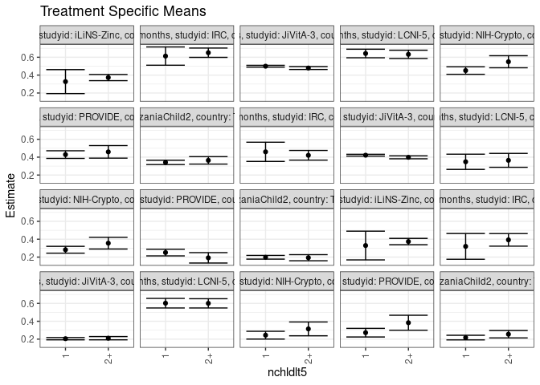

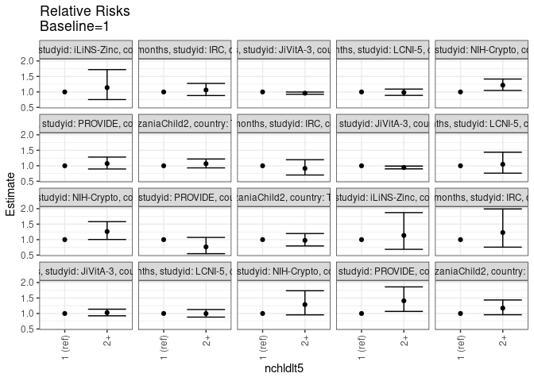

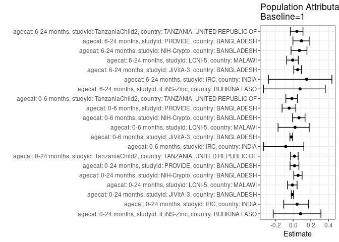

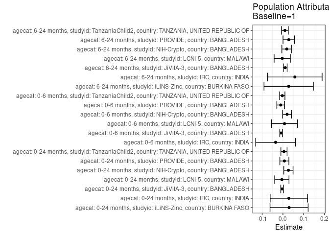

## Results Table

### Parameter: TSM

| agecat | studyid | country | intervention_level | baseline_level | estimate | ci_lower | ci_upper |
| --- | --- | --- | --- | --- | --- | --- | --- |
| 0-24 months | iLiNS-Zinc | BURKINA FASO | 1 | NA | 0.3272611 | 0.1931131 | 0.4614091 |
| 0-24 months | iLiNS-Zinc | BURKINA FASO | 2+ | NA | 0.3727760 | 0.3380103 | 0.4075417 |
| 0-24 months | IRC | INDIA | 1 | NA | 0.6128762 | 0.5108051 | 0.7149472 |
| 0-24 months | IRC | INDIA | 2+ | NA | 0.6504776 | 0.5983675 | 0.7025878 |
| 0-24 months | JiVitA-3 | BANGLADESH | 1 | NA | 0.4995112 | 0.4892558 | 0.5097666 |
| 0-24 months | JiVitA-3 | BANGLADESH | 2+ | NA | 0.4793149 | 0.4630708 | 0.4955589 |
| 0-24 months | LCNI-5 | MALAWI | 1 | NA | 0.6418952 | 0.5939339 | 0.6898565 |
| 0-24 months | LCNI-5 | MALAWI | 2+ | NA | 0.6322864 | 0.5860394 | 0.6785333 |
| 0-24 months | NIH-Crypto | BANGLADESH | 1 | NA | 0.4510598 | 0.4091972 | 0.4929223 |
| 0-24 months | NIH-Crypto | BANGLADESH | 2+ | NA | 0.5495233 | 0.4820848 | 0.6169619 |
| 0-24 months | PROVIDE | BANGLADESH | 1 | NA | 0.4286956 | 0.3860124 | 0.4713789 |
| 0-24 months | PROVIDE | BANGLADESH | 2+ | NA | 0.4593433 | 0.3891192 | 0.5295674 |
| 0-24 months | TanzaniaChild2 | TANZANIA, UNITED REPUBLIC OF | 1 | NA | 0.3416719 | 0.3174172 | 0.3659266 |
| 0-24 months | TanzaniaChild2 | TANZANIA, UNITED REPUBLIC OF | 2+ | NA | 0.3642583 | 0.3226119 | 0.4059047 |
| 0-6 months | IRC | INDIA | 1 | NA | 0.4597025 | 0.3522173 | 0.5671877 |
| 0-6 months | IRC | INDIA | 2+ | NA | 0.4209722 | 0.3667908 | 0.4751535 |
| 0-6 months | JiVitA-3 | BANGLADESH | 1 | NA | 0.4218871 | 0.4117092 | 0.4320650 |
| 0-6 months | JiVitA-3 | BANGLADESH | 2+ | NA | 0.3982811 | 0.3817246 | 0.4148375 |
| 0-6 months | LCNI-5 | MALAWI | 1 | NA | 0.3482281 | 0.2630538 | 0.4334024 |
| 0-6 months | LCNI-5 | MALAWI | 2+ | NA | 0.3645318 | 0.2868712 | 0.4421925 |
| 0-6 months | NIH-Crypto | BANGLADESH | 1 | NA | 0.2820186 | 0.2439159 | 0.3201214 |
| 0-6 months | NIH-Crypto | BANGLADESH | 2+ | NA | 0.3556235 | 0.2902572 | 0.4209898 |
| 0-6 months | PROVIDE | BANGLADESH | 1 | NA | 0.2507612 | 0.2132643 | 0.2882582 |
| 0-6 months | PROVIDE | BANGLADESH | 2+ | NA | 0.1917908 | 0.1335532 | 0.2500283 |
| 0-6 months | TanzaniaChild2 | TANZANIA, UNITED REPUBLIC OF | 1 | NA | 0.1979652 | 0.1772144 | 0.2187160 |
| 0-6 months | TanzaniaChild2 | TANZANIA, UNITED REPUBLIC OF | 2+ | NA | 0.1931377 | 0.1591432 | 0.2271322 |
| 6-24 months | iLiNS-Zinc | BURKINA FASO | 1 | NA | 0.3292124 | 0.1684803 | 0.4899445 |
| 6-24 months | iLiNS-Zinc | BURKINA FASO | 2+ | NA | 0.3736690 | 0.3381060 | 0.4092320 |
| 6-24 months | IRC | INDIA | 1 | NA | 0.3195991 | 0.1755966 | 0.4636015 |
| 6-24 months | IRC | INDIA | 2+ | NA | 0.3926395 | 0.3223666 | 0.4629124 |
| 6-24 months | JiVitA-3 | BANGLADESH | 1 | NA | 0.2051359 | 0.1923510 | 0.2179209 |
| 6-24 months | JiVitA-3 | BANGLADESH | 2+ | NA | 0.2104971 | 0.1920315 | 0.2289627 |
| 6-24 months | LCNI-5 | MALAWI | 1 | NA | 0.6019751 | 0.5485633 | 0.6553869 |
| 6-24 months | LCNI-5 | MALAWI | 2+ | NA | 0.6004060 | 0.5487065 | 0.6521055 |
| 6-24 months | NIH-Crypto | BANGLADESH | 1 | NA | 0.2443392 | 0.2008099 | 0.2878686 |
| 6-24 months | NIH-Crypto | BANGLADESH | 2+ | NA | 0.3144697 | 0.2372740 | 0.3916654 |
| 6-24 months | PROVIDE | BANGLADESH | 1 | NA | 0.2722487 | 0.2240786 | 0.3204189 |
| 6-24 months | PROVIDE | BANGLADESH | 2+ | NA | 0.3834000 | 0.2997135 | 0.4670866 |
| 6-24 months | TanzaniaChild2 | TANZANIA, UNITED REPUBLIC OF | 1 | NA | 0.2172349 | 0.1913250 | 0.2431449 |
| 6-24 months | TanzaniaChild2 | TANZANIA, UNITED REPUBLIC OF | 2+ | NA | 0.2549615 | 0.2134218 | 0.2965012 |

### Parameter: E(Y)

| agecat | studyid | country | intervention_level | baseline_level | estimate | ci_lower | ci_upper |
| --- | --- | --- | --- | --- | --- | --- | --- |
| 0-24 months | iLiNS-Zinc | BURKINA FASO | NA | NA | 0.3569636 | 0.3068991 | 0.4070281 |
| 0-24 months | IRC | INDIA | NA | NA | 0.6414634 | 0.5949863 | 0.6879405 |
| 0-24 months | JiVitA-3 | BANGLADESH | NA | NA | 0.4954044 | 0.4875673 | 0.5032416 |
| 0-24 months | LCNI-5 | MALAWI | NA | NA | 0.6366995 | 0.6035988 | 0.6698003 |
| 0-24 months | NIH-Crypto | BANGLADESH | NA | NA | 0.4775726 | 0.4419904 | 0.5131548 |
| 0-24 months | PROVIDE | BANGLADESH | NA | NA | 0.4357143 | 0.3989556 | 0.4724730 |
| 0-24 months | TanzaniaChild2 | TANZANIA, UNITED REPUBLIC OF | NA | NA | 0.3467505 | 0.3276457 | 0.3658553 |
| 0-6 months | IRC | INDIA | NA | NA | 0.4243902 | 0.3764905 | 0.4722900 |
| 0-6 months | JiVitA-3 | BANGLADESH | NA | NA | 0.4130611 | 0.4056124 | 0.4205098 |
| 0-6 months | LCNI-5 | MALAWI | NA | NA | 0.3558052 | 0.2982716 | 0.4133389 |
| 0-6 months | NIH-Crypto | BANGLADESH | NA | NA | 0.3021108 | 0.2694011 | 0.3348205 |
| 0-6 months | PROVIDE | BANGLADESH | NA | NA | 0.2400000 | 0.2083392 | 0.2716608 |
| 0-6 months | TanzaniaChild2 | TANZANIA, UNITED REPUBLIC OF | NA | NA | 0.1949686 | 0.1790654 | 0.2108717 |
| 6-24 months | iLiNS-Zinc | BURKINA FASO | NA | NA | 0.3569636 | 0.3068991 | 0.4070281 |
| 6-24 months | IRC | INDIA | NA | NA | 0.3771186 | 0.3151523 | 0.4390850 |
| 6-24 months | JiVitA-3 | BANGLADESH | NA | NA | 0.2161724 | 0.2067972 | 0.2255476 |
| 6-24 months | LCNI-5 | MALAWI | NA | NA | 0.5985816 | 0.5623721 | 0.6347910 |
| 6-24 months | NIH-Crypto | BANGLADESH | NA | NA | 0.2628458 | 0.2244546 | 0.3012371 |
| 6-24 months | PROVIDE | BANGLADESH | NA | NA | 0.3004386 | 0.2583143 | 0.3425629 |
| 6-24 months | TanzaniaChild2 | TANZANIA, UNITED REPUBLIC OF | NA | NA | 0.2268170 | 0.2062654 | 0.2473687 |

### Parameter: RR

| agecat | studyid | country | intervention_level | baseline_level | estimate | ci_lower | ci_upper |
| --- | --- | --- | --- | --- | --- | --- | --- |
| 0-24 months | iLiNS-Zinc | BURKINA FASO | 1 | 1 | 1.0000000 | 1.0000000 | 1.0000000 |
| 0-24 months | iLiNS-Zinc | BURKINA FASO | 2+ | 1 | 1.1390783 | 0.7537453 | 1.7214029 |
| 0-24 months | IRC | INDIA | 1 | 1 | 1.0000000 | 1.0000000 | 1.0000000 |
| 0-24 months | IRC | INDIA | 2+ | 1 | 1.0613525 | 0.8833696 | 1.2751956 |
| 0-24 months | JiVitA-3 | BANGLADESH | 1 | 1 | 1.0000000 | 1.0000000 | 1.0000000 |
| 0-24 months | JiVitA-3 | BANGLADESH | 2+ | 1 | 0.9595677 | 0.9245062 | 0.9959589 |
| 0-24 months | LCNI-5 | MALAWI | 1 | 1 | 1.0000000 | 1.0000000 | 1.0000000 |
| 0-24 months | LCNI-5 | MALAWI | 2+ | 1 | 0.9850305 | 0.8885110 | 1.0920350 |
| 0-24 months | NIH-Crypto | BANGLADESH | 1 | 1 | 1.0000000 | 1.0000000 | 1.0000000 |
| 0-24 months | NIH-Crypto | BANGLADESH | 2+ | 1 | 1.2182939 | 1.0474095 | 1.4170580 |
| 0-24 months | PROVIDE | BANGLADESH | 1 | 1 | 1.0000000 | 1.0000000 | 1.0000000 |
| 0-24 months | PROVIDE | BANGLADESH | 2+ | 1 | 1.0714905 | 0.8962120 | 1.2810494 |
| 0-24 months | TanzaniaChild2 | TANZANIA, UNITED REPUBLIC OF | 1 | 1 | 1.0000000 | 1.0000000 | 1.0000000 |
| 0-24 months | TanzaniaChild2 | TANZANIA, UNITED REPUBLIC OF | 2+ | 1 | 1.0661056 | 0.9323714 | 1.2190219 |
| 0-6 months | IRC | INDIA | 1 | 1 | 1.0000000 | 1.0000000 | 1.0000000 |
| 0-6 months | IRC | INDIA | 2+ | 1 | 0.9157491 | 0.7014152 | 1.1955778 |
| 0-6 months | JiVitA-3 | BANGLADESH | 1 | 1 | 1.0000000 | 1.0000000 | 1.0000000 |
| 0-6 months | JiVitA-3 | BANGLADESH | 2+ | 1 | 0.9440465 | 0.9008400 | 0.9893252 |
| 0-6 months | LCNI-5 | MALAWI | 1 | 1 | 1.0000000 | 1.0000000 | 1.0000000 |
| 0-6 months | LCNI-5 | MALAWI | 2+ | 1 | 1.0468192 | 0.7615754 | 1.4388995 |
| 0-6 months | NIH-Crypto | BANGLADESH | 1 | 1 | 1.0000000 | 1.0000000 | 1.0000000 |
| 0-6 months | NIH-Crypto | BANGLADESH | 2+ | 1 | 1.2609929 | 1.0053567 | 1.5816308 |
| 0-6 months | PROVIDE | BANGLADESH | 1 | 1 | 1.0000000 | 1.0000000 | 1.0000000 |
| 0-6 months | PROVIDE | BANGLADESH | 2+ | 1 | 0.7648342 | 0.5458568 | 1.0716570 |
| 0-6 months | TanzaniaChild2 | TANZANIA, UNITED REPUBLIC OF | 1 | 1 | 1.0000000 | 1.0000000 | 1.0000000 |
| 0-6 months | TanzaniaChild2 | TANZANIA, UNITED REPUBLIC OF | 2+ | 1 | 0.9756142 | 0.7956461 | 1.1962896 |
| 6-24 months | iLiNS-Zinc | BURKINA FASO | 1 | 1 | 1.0000000 | 1.0000000 | 1.0000000 |
| 6-24 months | iLiNS-Zinc | BURKINA FASO | 2+ | 1 | 1.1350394 | 0.6876434 | 1.8735211 |
| 6-24 months | IRC | INDIA | 1 | 1 | 1.0000000 | 1.0000000 | 1.0000000 |
| 6-24 months | IRC | INDIA | 2+ | 1 | 1.2285377 | 0.7576846 | 1.9919963 |
| 6-24 months | JiVitA-3 | BANGLADESH | 1 | 1 | 1.0000000 | 1.0000000 | 1.0000000 |
| 6-24 months | JiVitA-3 | BANGLADESH | 2+ | 1 | 1.0261344 | 0.9248535 | 1.1385067 |
| 6-24 months | LCNI-5 | MALAWI | 1 | 1 | 1.0000000 | 1.0000000 | 1.0000000 |
| 6-24 months | LCNI-5 | MALAWI | 2+ | 1 | 0.9973934 | 0.8826924 | 1.1269992 |
| 6-24 months | NIH-Crypto | BANGLADESH | 1 | 1 | 1.0000000 | 1.0000000 | 1.0000000 |
| 6-24 months | NIH-Crypto | BANGLADESH | 2+ | 1 | 1.2870210 | 0.9553357 | 1.7338649 |
| 6-24 months | PROVIDE | BANGLADESH | 1 | 1 | 1.0000000 | 1.0000000 | 1.0000000 |
| 6-24 months | PROVIDE | BANGLADESH | 2+ | 1 | 1.4082713 | 1.0667430 | 1.8591432 |
| 6-24 months | TanzaniaChild2 | TANZANIA, UNITED REPUBLIC OF | 1 | 1 | 1.0000000 | 1.0000000 | 1.0000000 |
| 6-24 months | TanzaniaChild2 | TANZANIA, UNITED REPUBLIC OF | 2+ | 1 | 1.1736671 | 0.9592351 | 1.4360342 |

### Parameter: PAR

| agecat | studyid | country | intervention_level | baseline_level | estimate | ci_lower | ci_upper |
| --- | --- | --- | --- | --- | --- | --- | --- |
| 0-24 months | iLiNS-Zinc | BURKINA FASO | 1 | NA | 0.0297025 | -0.0621804 | 0.1215855 |
| 0-24 months | IRC | INDIA | 1 | NA | 0.0285872 | -0.0615760 | 0.1187505 |
| 0-24 months | JiVitA-3 | BANGLADESH | 1 | NA | -0.0041068 | -0.0103071 | 0.0020934 |
| 0-24 months | LCNI-5 | MALAWI | 1 | NA | -0.0051957 | -0.0396513 | 0.0292600 |
| 0-24 months | NIH-Crypto | BANGLADESH | 1 | NA | 0.0265128 | 0.0042158 | 0.0488098 |
| 0-24 months | PROVIDE | BANGLADESH | 1 | NA | 0.0070186 | -0.0147916 | 0.0288288 |
| 0-24 months | TanzaniaChild2 | TANZANIA, UNITED REPUBLIC OF | 1 | NA | 0.0050786 | -0.0098519 | 0.0200091 |
| 0-6 months | IRC | INDIA | 1 | NA | -0.0353123 | -0.1312442 | 0.0606197 |
| 0-6 months | JiVitA-3 | BANGLADESH | 1 | NA | -0.0088260 | -0.0151672 | -0.0024849 |
| 0-6 months | LCNI-5 | MALAWI | 1 | NA | 0.0075772 | -0.0548638 | 0.0700182 |
| 0-6 months | NIH-Crypto | BANGLADESH | 1 | NA | 0.0200922 | -0.0012630 | 0.0414474 |
| 0-6 months | PROVIDE | BANGLADESH | 1 | NA | -0.0107612 | -0.0293950 | 0.0078726 |
| 0-6 months | TanzaniaChild2 | TANZANIA, UNITED REPUBLIC OF | 1 | NA | -0.0029967 | -0.0157010 | 0.0097077 |
| 6-24 months | iLiNS-Zinc | BURKINA FASO | 1 | NA | 0.0277512 | -0.0911917 | 0.1466942 |
| 6-24 months | IRC | INDIA | 1 | NA | 0.0575196 | -0.0738804 | 0.1889196 |
| 6-24 months | JiVitA-3 | BANGLADESH | 1 | NA | 0.0110365 | 0.0017447 | 0.0203282 |
| 6-24 months | LCNI-5 | MALAWI | 1 | NA | -0.0033936 | -0.0425527 | 0.0357656 |
| 6-24 months | NIH-Crypto | BANGLADESH | 1 | NA | 0.0185066 | -0.0051907 | 0.0422039 |
| 6-24 months | PROVIDE | BANGLADESH | 1 | NA | 0.0281899 | 0.0004827 | 0.0558970 |
| 6-24 months | TanzaniaChild2 | TANZANIA, UNITED REPUBLIC OF | 1 | NA | 0.0095821 | -0.0065935 | 0.0257577 |

### Parameter: PAF

| agecat | studyid | country | intervention_level | baseline_level | estimate | ci_lower | ci_upper |
| --- | --- | --- | --- | --- | --- | --- | --- |
| 0-24 months | iLiNS-Zinc | BURKINA FASO | 1 | NA | 0.0832088 | -0.2259953 | 0.3144296 |
| 0-24 months | IRC | INDIA | 1 | NA | 0.0445657 | -0.1069589 | 0.1753490 |
| 0-24 months | JiVitA-3 | BANGLADESH | 1 | NA | -0.0082899 | -0.0208768 | 0.0041419 |
| 0-24 months | LCNI-5 | MALAWI | 1 | NA | -0.0081603 | -0.0637535 | 0.0445274 |
| 0-24 months | NIH-Crypto | BANGLADESH | 1 | NA | 0.0555157 | 0.0074916 | 0.1012162 |
| 0-24 months | PROVIDE | BANGLADESH | 1 | NA | 0.0161084 | -0.0352580 | 0.0649260 |
| 0-24 months | TanzaniaChild2 | TANZANIA, UNITED REPUBLIC OF | 1 | NA | 0.0146463 | -0.0293751 | 0.0567852 |
| 0-6 months | IRC | INDIA | 1 | NA | -0.0832071 | -0.3347397 | 0.1209240 |
| 0-6 months | JiVitA-3 | BANGLADESH | 1 | NA | -0.0213674 | -0.0368072 | -0.0061575 |
| 0-6 months | LCNI-5 | MALAWI | 1 | NA | 0.0212958 | -0.1709808 | 0.1820003 |
| 0-6 months | NIH-Crypto | BANGLADESH | 1 | NA | 0.0665060 | -0.0069091 | 0.1345682 |
| 0-6 months | PROVIDE | BANGLADESH | 1 | NA | -0.0448384 | -0.1253749 | 0.0299345 |
| 0-6 months | TanzaniaChild2 | TANZANIA, UNITED REPUBLIC OF | 1 | NA | -0.0153699 | -0.0826260 | 0.0477080 |
| 6-24 months | iLiNS-Zinc | BURKINA FASO | 1 | NA | 0.0777425 | -0.3358329 | 0.3632745 |
| 6-24 months | IRC | INDIA | 1 | NA | 0.1525238 | -0.2789517 | 0.4384340 |
| 6-24 months | JiVitA-3 | BANGLADESH | 1 | NA | 0.0510539 | 0.0071664 | 0.0930015 |
| 6-24 months | LCNI-5 | MALAWI | 1 | NA | -0.0056694 | -0.0732639 | 0.0576681 |
| 6-24 months | NIH-Crypto | BANGLADESH | 1 | NA | 0.0704086 | -0.0240351 | 0.1561421 |
| 6-24 months | PROVIDE | BANGLADESH | 1 | NA | 0.0938291 | -0.0029039 | 0.1812319 |
| 6-24 months | TanzaniaChild2 | TANZANIA, UNITED REPUBLIC OF | 1 | NA | 0.0422460 | -0.0318238 | 0.1109986 |